# Recurrent Neural Networks (RNNs)

## Comprehensive Lecture Notes

**Table of Contents**

1. Motivation and Sequence Modeling
2. Finite-Response Models
3. Long-Term Dependencies
4. NARX Networks
5. Explicit Memory Networks (Jordan & Elman)
6. State-Space Recurrent Neural Networks
7. Mathematical Formulation of RNNs
8. RNN Input–Output Variants
9. Training Objective for RNNs
10. Backpropagation Through Time (BPTT)
11. Bidirectional RNNs
12. Backpropagation in Bidirectional RNNs
13. Summary and Conceptual Unification

# 1. Motivation and Sequence Modeling

## 1.1 What Is a Sequence Modeling Problem?

In many real-world problems, inputs are **not independent**. Instead, they arrive as an **ordered sequence over time**. The fundamental challenge is to build models that can exploit temporal structure.

**Definition (Sequence):** A sequence is an ordered collection of vectors indexed by discrete time: $$ X = \{x(0), x(1), x(2), \ldots, x(T)\} $$

where:

- $x(t) \in \mathbb{R}^{d_x}$ is the input vector at time $t$
- $T$ is the sequence length (may vary across examples)
- The ordering $0 \to 1 \to \cdots \to T$ is essential

**Output Types:**

- **Scalar output:** A single decision or classification
- **Vector output:** A single prediction vector
- **Sequence output:** A sequence of outputs $\{y(0), y(1), \ldots, y(T')\}$

**Key Insight:**

> **Order matters** — the meaning of an input depends on what came before it. Swapping elements changes the semantics.

## 1.2 Examples of Sequence Problems

### Speech Recognition

- **Input:** Sequence of spectral feature vectors (e.g., MFCCs)
- **Output:** Spoken text (transcription)
- **Observation:** A single audio frame is meaningless in isolation; meaning emerges from the temporal context

### Text Analysis

- **Input:** Sequence of word embeddings or tokens
- **Outputs:**
  - Topic classification (many-to-one)
  - Machine translation (many-to-many)
  - Next-word prediction (autoregressive)

### Financial Prediction

- **Input:** Historical stock price vectors
- **Output:**
  - Buy/sell decision (classification)
  - Future price prediction (regression)
- **Key Property:** Decisions must consider *how* values evolved, not just the current state

## 1.3 Formal Problem Statement

**Given:**

- Input sequences: $X = \{x(0), x(1), \ldots, x(T)\}$ where $x(t) \in \mathbb{R}^{d_x}$
- Desired outputs: $D = \{d(0), d(1), \ldots, d(T')\}$

**Goal:** Learn a mapping $f: X \to Y$ that captures temporal dependencies.

**Challenge:** Standard multilayer perceptrons (MLPs) assume:

1. Fixed input dimension
2. Independent inputs

Both assumptions fail for sequences. This motivates specialized architectures.

# 2. Finite-Response Models

## 2.1 Representational Convention

**Diagrammatic Shortcut:** Throughout these notes, each box in a network diagram represents:

- An **entire layer** of neurons (not a single neuron)
- Inputs, hidden layers, and outputs are all **vector-valued**

This abstraction allows us to focus on temporal structure rather than individual neurons.

## 2.2 Sliding Window (Time-Delay) Predictor

### Core Idea

The simplest approach to sequence modeling is to use a **fixed window of past inputs** to predict the current output:

$$ y(t) = f\big(x(t), x(t-1), \ldots, x(t-N)\big) $$

where:

- $N$ is the **window size** (how far back we look)
- $f$ is typically a feedforward neural network (MLP)

**Alternative Names:**

- Sliding window predictor
- **Time-Delay Neural Network (TDNN)**

### Interpretation

- The **same network** is applied repeatedly over time
- The window **slides forward** at each time step
- **Parameters are shared** across time steps

**Mathematical Connection:**

> This is equivalent to applying a **convolutional neural network (CNN)** along the time axis, where the kernel size equals the window size $N+1$.

## 2.3 Finite Response Property

**Definition (Finite Response System):** A system has a **finite response** if an input at time $t$ affects the output only for a **limited number of future time steps**.

**Formal Statement:** For a TDNN with window size $N$: $$ \frac{\partial y(t+k)}{\partial x(t)} = 0 \quad \text{for all } k > N $$

**System Width:** The maximum number of time steps over which an input influences outputs. For a TDNN, this equals $N$.

**Example:** If the window size is $N = 5$:

- Input at day 0 affects outputs from day 0 to day 5
- At day 6 and beyond, the influence is **exactly zero**

## 2.4 Increasing the History

To capture longer dependencies, we can **increase the window size** $N$. However, this has costs:

| Window Size | Parameters | Computation | Memory |
| --- | --- | --- | --- |
| $N$ | $\mathcal{O}(N \cdot d_x \cdot d_h)$ | $\mathcal{O}(N \cdot d_x \cdot d_h)$ | $\mathcal{O}(N \cdot d_x)$ |
| $2N$ | $\mathcal{O}(2N \cdot d_x \cdot d_h)$ | $\mathcal{O}(2N \cdot d_x \cdot d_h)$ | $\mathcal{O}(2N \cdot d_x)$ |

**Trade-off:** Longer history requires proportionally larger networks.

## 2.5 Fundamental Limitation of Finite-Response Models

**Problem:** Many real-world systems exhibit **long-term dependencies**:

- Weekly trends (7-day cycles)
- Monthly cycles
- Seasonal or annual effects
- Slowly evolving patterns

**Key Observations:**

1. Older events often matter **less** than recent ones
2. But they do **not** become completely irrelevant
3. Influence should decay smoothly, not drop abruptly to zero

**Why TDNNs Fail:**

> Finite-response models have a **hard cutoff**: influence drops from nonzero to exactly zero at the window boundary.

## 2.6 Summary: Finite-Response Models

**Strengths:**

- Simple architecture
- Easy to train (standard backpropagation)
- Parallel computation possible

**Weaknesses:**

- Fixed, limited memory
- Cannot model long-term dependencies
- Abrupt memory cutoff

**Conclusion:** Sequence problems often require **infinite or long-term memory**. This motivates **recurrent models** that use recursion to maintain memory of the past.

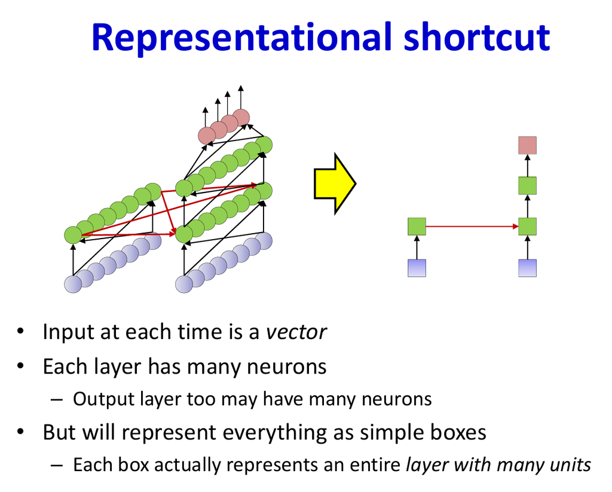

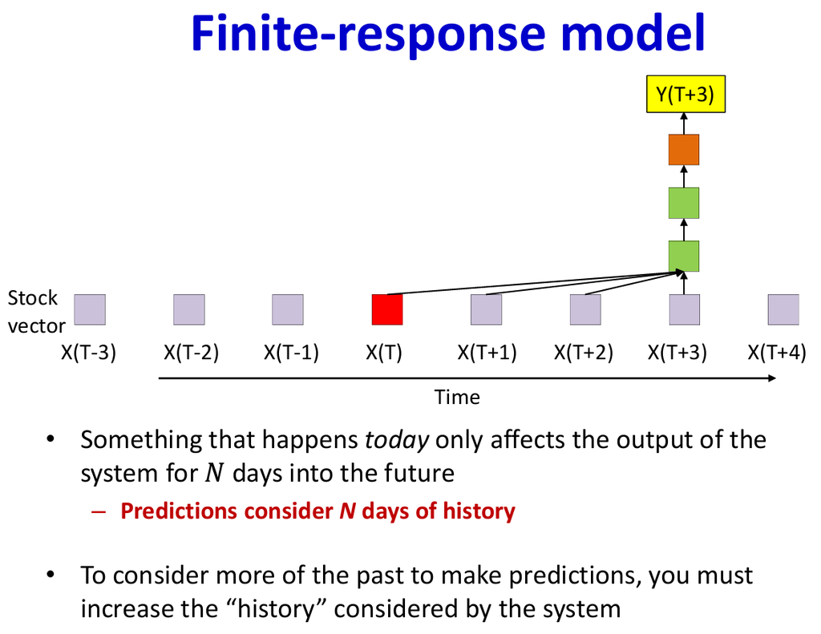

# 3. Long-Term Dependencies

## 3.1 The Problem

Many sequence problems exhibit dependencies spanning **long time horizons**:

**Examples:**

- **Weekly trends:** Stock patterns that repeat every 7 days
- **Monthly cycles:** Customer behavior patterns
- **Seasonal effects:** Annual variations in data
- **Slowly evolving patterns:** Gradual drift in time series

**Key Observation:**

> Finite-response models **fail** because they forget the past completely beyond a fixed window.

## 3.2 Desired Property: Infinite Response

**Definition (Infinite Response System):** A system has **infinite response** if an input at time $t$ can influence outputs **arbitrarily far in the future**.

Mathematically, for an infinite response system: $$ \frac{\partial y(t+k)}{\partial x(t)} \neq 0 \quad \text{for potentially all } k \geq 0 $$

**Key Insight:**

> The influence may **decay** over time, but it never becomes exactly zero.

This property requires **recursion**: the output or internal state at time $t$ must depend on values computed at earlier times.

# 4. NARX Networks (Output-Based Recurrence)

## 4.1 Core Idea

**NARX (Nonlinear AutoRegressive with eXogenous inputs)** networks introduce recursion by **feeding back past outputs**.

**NARX Equation:** $$ y(t) = f\big(y(t-1), y(t-2), \ldots, y(t-K), \; x(t), x(t-1), \ldots, x(t-L)\big) $$

where:

- $K$ = number of past outputs fed back
- $L$ = number of past inputs considered
- $f$ = nonlinear function (typically an MLP)

## 4.2 Properties of NARX Networks

**Infinite Response:** NARX networks are infinite response systems because:

1. Output $y(t-1)$ depends on $y(t-2)$
2. Which depends on $y(t-3)$, and so on...
3. Therefore, $x(0)$ can influence $y(T)$ for arbitrarily large $T$

**Memory Storage:** Memory is stored **implicitly in the output sequence itself**.

## 4.3 Limitations of NARX

1. **No explicit internal state:** The network has no dedicated memory representation
2. **Memory is not abstracted:** Past information is not compressed into a learned representation
3. **Training complexity:** Errors in outputs compound through the recurrence
4. **Output prediction only:** Cannot form internal representations of past context

# 5. Explicit Memory Networks (Jordan & Elman)

These models introduce **dedicated memory units** instead of relying solely on output feedback.

## 5.1 Jordan Networks

**Key Features:**

- Introduce a **memory unit** that stores a running average of past outputs
- Memory structure is **fixed** (not learned)
- Memory update: $m(t) = \alpha \cdot m(t-1) + (1-\alpha) \cdot y(t-1)$

**Limitations:**

- No learning of **how to remember**
- Past errors do **not propagate** through the memory update

## 5.2 Elman Networks

**Key Features:**

- Introduce **context units** that store the previous hidden state
- Context: $c(t) = h(t-1)$
- Hidden state: $h(t) = f(W_x x(t) + W_c c(t) + b)$

**Partial Recurrence:**

- The context provides information about the past
- However, during training, gradients are **not backpropagated** through the context copy operation

## 5.3 Comparison of Early Architectures

| Model | Memory Location | True Recurrence | Gradient Through Time | Trainable Memory |
| --- | --- | --- | --- | --- |
| Finite-response (TDNN) | None | ✗ | ✗ | ✗ |
| NARX | Output | Partial | Limited | ✗ |
| Jordan | Memory unit | Partial | Blocked | ✗ |
| Elman | Context unit | Partial | Blocked | ✗ |

## 5.4 Why These Are "Early" RNN Ideas

These architectures represent **important historical steps** but have fundamental limitations:

1. Memory exists but is **not fully trainable**
2. No true **state-space formulation**
3. Long-term dependencies **cannot be learned effectively**
4. Gradient information does not flow across time

**Motivation:** These limitations led to the development of **fully recurrent state-based RNNs** where gradients flow through time.

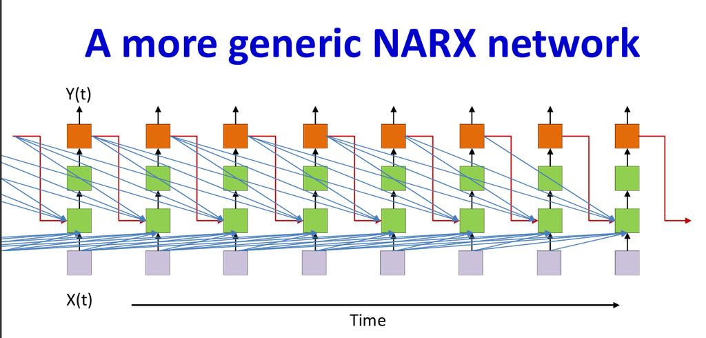

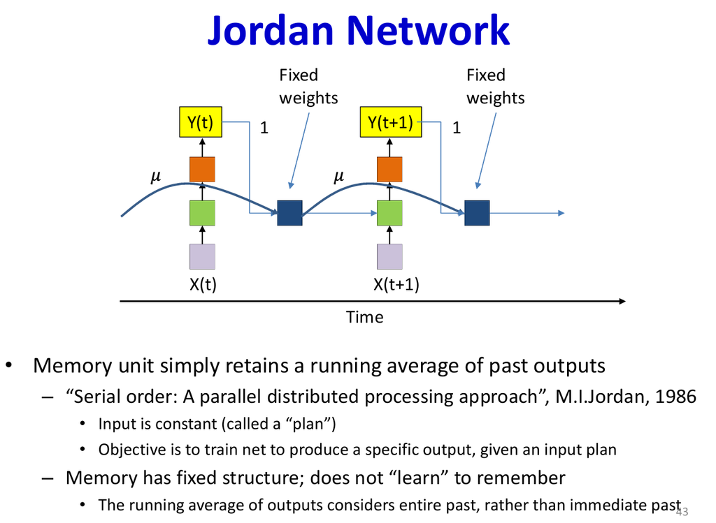

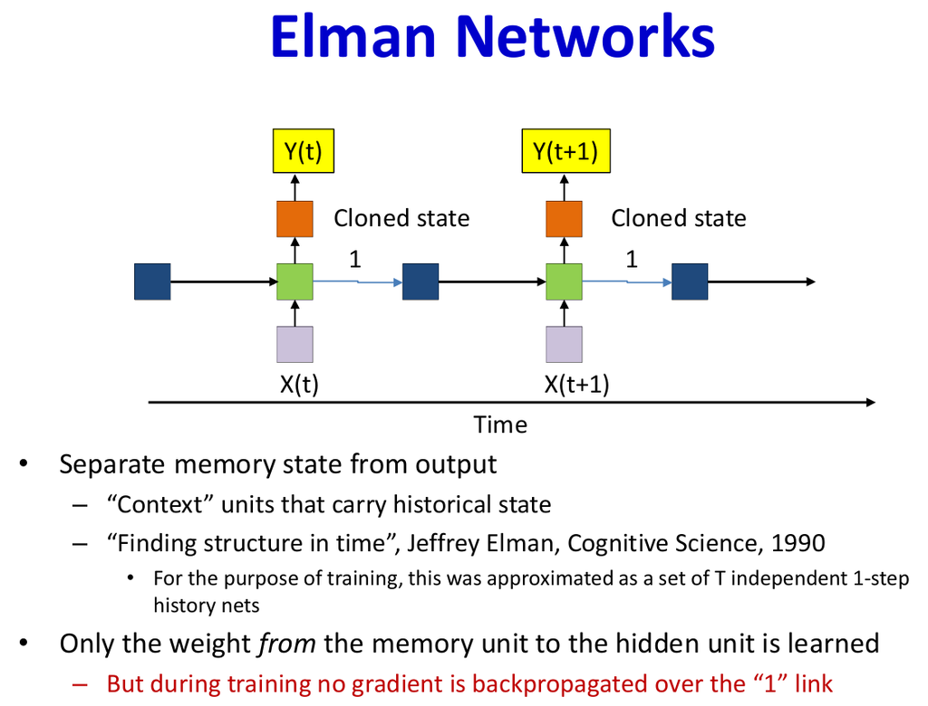

# 6. State-Space Recurrent Neural Networks (True RNNs)

## 6.1 Motivation for State-Space Models

Earlier models had critical limitations:

- **Finite-response models:** Limited memory window
- **NARX:** Memory in outputs, not abstracted
- **Jordan/Elman:** Memory not trainable, gradients blocked

**Goal:** Design a model where:

1. Memory is **trainable**
2. Gradients flow **through time**
3. The model can **learn what to remember**

## 6.2 Core Idea: Hidden State as Memory

A **state-space RNN** maintains an internal **hidden state** $h(t)$ that summarizes the entire past.

**Key Concept:**

> The hidden state is the **memory** of the network. It is a learned, compressed representation of all past inputs.

**Variables at time $t$:**

- $x(t) \in \mathbb{R}^{d_x}$: Input vector
- $h(t) \in \mathbb{R}^{d_h}$: Hidden state (memory)
- $y(t) \in \mathbb{R}^{d_y}$: Output vector

**State Evolution (Recurrence):** $$ h(t) = f\big(x(t), h(t-1)\big) $$

**Output Generation:** $$ y(t) = g\big(h(t)\big) $$

where $f$ and $g$ are parameterized functions (neural networks).

## 6.3 Infinite Response Property

The hidden state is **recursive**: it depends on the previous hidden state, which depends on earlier states.

**Consequence:** An input at $t=0$ influences: $$ h(0) \to h(1) \to h(2) \to \cdots \to h(T) $$

And therefore influences all future outputs $y(1), y(2), \ldots, y(T)$.

**Conclusion:**

> State-space RNNs are **infinite response systems**. This is the defining property of true recurrent neural networks.

## 6.4 Unrolled View of an RNN

Although we **draw** an RNN with loops (compact notation), it can be **equivalently viewed** as:

- A **deep feedforward network**
- One "layer" per time step
- All layers **share parameters**

This is called **unrolling through time**.

**Compact View:**

```
     ┌─────────────────┐
     │     RNN Cell    │◄─── h(t-1)
     │  (shared weights)│
     └────────┬────────┘
              │
         x(t) ▼
         ─────►  h(t)  ────► y(t)
```

**Unrolled View:**

```
x(0)    x(1)    x(2)         x(T)
 │       │       │             │
 ▼       ▼       ▼             ▼
[Cell]─►[Cell]─►[Cell]─► ··· ─►[Cell]
 │       │       │             │
 ▼       ▼       ▼             ▼
y(0)    y(1)    y(2)         y(T)
```

**Implications:**

1. Same weights $W_c, W_r, W_o$ used at **all** time steps
2. Learning requires **aggregating gradients** across time

## 6.5 Single-Layer vs Multi-Layer RNNs

### Single-Layer RNN

- One recurrent hidden layer
- Simplest and most common formulation
- Hidden state dimension $d_h$ controls capacity

### Multi-Layer (Deep) RNN

- Multiple stacked recurrent hidden layers
- Each layer has its **own** hidden state: $h^{(1)}(t), h^{(2)}(t), \ldots, h^{(L)}(t)$
- Can model more complex temporal abstractions

**Key Property:** All time columns are **structurally identical** (parameter sharing across time).

## 6.6 Initial State

The **initial hidden state** $h(-1)$ (or $h(0)$ depending on convention):

- Must be **defined** before processing begins
- Common choices:
  1. Set to zero: $h(-1) = \mathbf{0}$
  2. Learned parameter: $h(-1) = h_{\text{init}}$ (trained)
  3. Computed from initial input

**Interpretation:** The initial state acts as **prior memory** before the sequence starts.

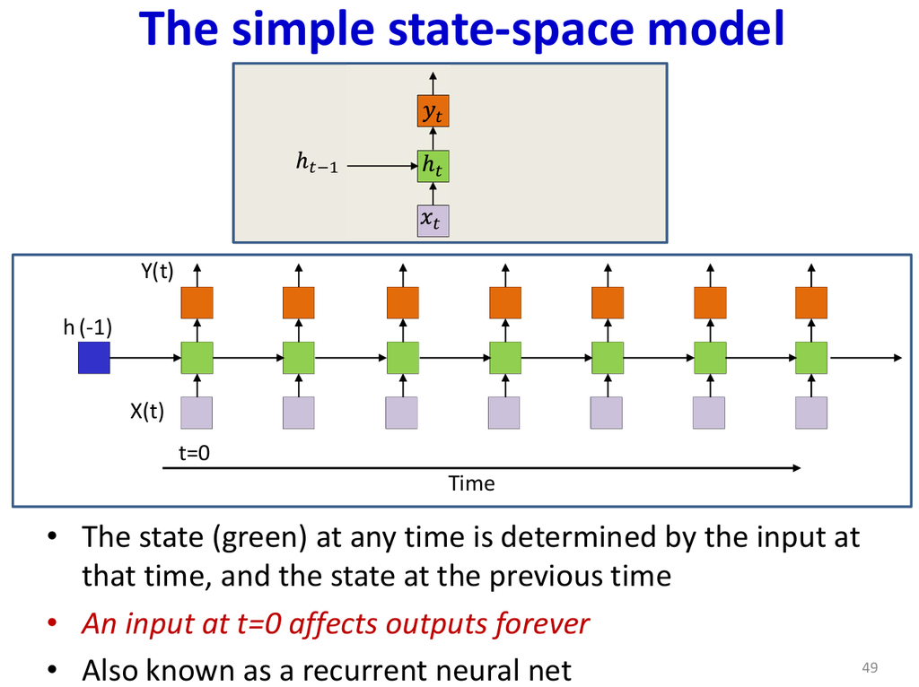

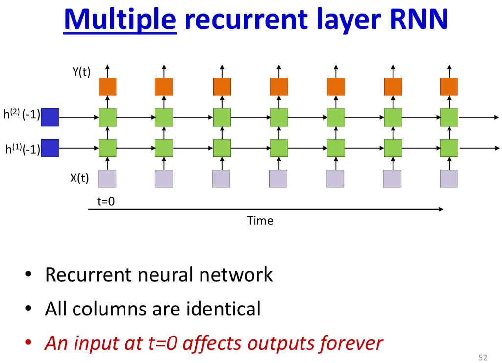

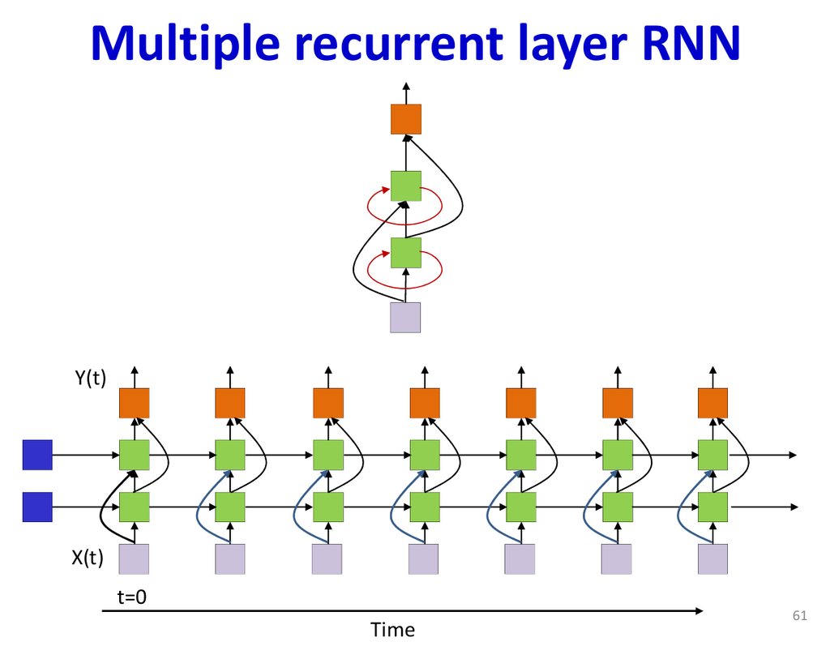

# 7. Mathematical Formulation of RNNs

## 7.1 Notation Overview

**Variable Definitions:**

| Symbol | Meaning | Dimension |
| --- | --- | --- |
| $x(t)$ | Input at time $t$ | $\mathbb{R}^{d_x}$ |
| $h(t)$ | Hidden state at time $t$ | $\mathbb{R}^{d_h}$ |
| $h^{(l)}(t)$ | Hidden state of layer $l$ at time $t$ | $\mathbb{R}^{d_h^{(l)}}$ |
| $y(t)$ | Output at time $t$ | $\mathbb{R}^{d_y}$ |
| $z(t)$ | Pre-activation at time $t$ | $\mathbb{R}^{d_h}$ |

**Weight Matrices:**

| Symbol | Meaning | Dimension |
| --- | --- | --- |
| $W_c$ or $W_c^{(l)}$ | **Current** weights (input-to-hidden) | $\mathbb{R}^{d_h \times d_{\text{in}}}$ |
| $W_r$ or $W_r^{(l)}$ | **Recurrent** weights (hidden-to-hidden) | $\mathbb{R}^{d_h \times d_h}$ |
| $W_o$ | **Output** weights (hidden-to-output) | $\mathbb{R}^{d_y \times d_h}$ |
| $b$, $b^{(l)}$, $b_o$ | Bias vectors | Appropriate dimensions |

## 7.2 Single-Hidden-Layer RNN Equations

### Hidden State Update

**Pre-activation:** $$ z(t) = W_c \, x(t) + W_r \, h(t-1) + b $$

**Hidden state (post-activation):** $$ h(t) = f\big(z(t)\big) = \tanh\big(W_c \, x(t) + W_r \, h(t-1) + b\big) $$

**Breaking down the equation:**

- $W_c \, x(t)$: How the **current input** influences the state
- $W_r \, h(t-1)$: How the **previous state** (memory) influences the current state
- $b$: Bias term for flexibility

**Why tanh?**

- Zero-centered output in $(-1, +1)$
- Bounded values prevent state explosion
- Smooth, differentiable

### Output Equation

$$ y(t) = g\big(W_o \, h(t) + b_o\big) $$

where $g(\cdot)$ depends on the task:

- **Classification:** $g = \text{softmax}$
- **Regression:** $g = \text{identity (linear)}$
- **Binary:** $g = \text{sigmoid}$

## 7.3 Multi-Layer RNN Equations

For a deep RNN with $L$ hidden layers, at layer $l \in \{1, 2, \ldots, L\}$:

**Layer 1 (receives input):** $$ h^{(1)}(t) = \tanh\big(W_c^{(1)} \, x(t) + W_r^{(1)} \, h^{(1)}(t-1) + b^{(1)}\big) $$

**Layer $l > 1$ (receives from layer below):** $$ h^{(l)}(t) = \tanh\big(W_c^{(l)} \, h^{(l-1)}(t) + W_r^{(l)} \, h^{(l)}(t-1) + b^{(l)}\big) $$

**Output layer:** $$ y(t) = f_o\big(W_o \, h^{(L)}(t) + b_o\big) $$

**Key Points:**

- Each layer has its **own** recurrent connection
- $W_c^{(l)}$ connects layer $l-1$ to layer $l$ (vertical)
- $W_r^{(l)}$ connects layer $l$ to itself across time (horizontal)
- All parameters are **shared across time**

## 7.4 Role of Activations

**Why tanh for hidden states?**

1. **Zero-centered:** Output mean is approximately 0
2. **Bounded:** Prevents unbounded growth of state values
3. **Smooth gradients:** Derivative is well-behaved (though can vanish)

**Activation derivative:** $$ \tanh'(z) = 1 - \tanh^2(z) $$

**Note:** Since $|\tanh(z)| < 1$, we have $0 < \tanh'(z) \leq 1$.

## 7.5 Interpretation as a Dynamical System

An RNN can be viewed as a **nonlinear discrete-time dynamical system**:

$$ h(t) = \phi\big(h(t-1), x(t); \theta\big) $$

where:

- **Hidden state** $h(t)$ = system state
- **Input** $x(t)$ = external excitation/forcing
- **Output** $y(t)$ = observation of the system
- **Parameters** $\theta = \{W_c, W_r, W_o, b, b_o\}$

This viewpoint explains:

- **Stability issues:** Some parameter configurations lead to divergent states
- **Vanishing/exploding gradients:** Related to Lyapunov exponents of the system
- **Long-term memory:** Related to the system's ability to maintain stable fixed points or limit cycles

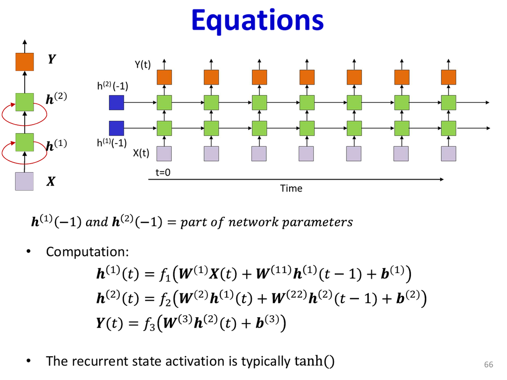

# 8. RNN Input–Output Variants

RNNs can be adapted to various tasks by changing the **input–output structure**.

## 8.1 One-to-One (Standard MLP)

```
x ──► [Network] ──► y
```

- **Input:** Single vector
- **Output:** Single vector
- **Temporal modeling:** None
- **Example:** Image classification
- **Note:** This is a degenerate case; no recurrence is needed

## 8.2 One-to-Many (Sequence Generation)

```
x ──► [RNN] ──► y(0) ──► y(1) ──► ... ──► y(T)
```

- **Input:** Single vector (or no input after first step)
- **Output:** Sequence
- **Examples:**
  - Image → caption generation
  - Music generation from a theme
  - Text generation from a prompt

**Mechanism:**

1. Input initializes the hidden state: $h(0) = f(W_c x)$
2. RNN generates outputs **autoregressively:** $y(t)$ feeds back as input

## 8.3 Many-to-One (Sequence Classification)

```
x(0) ──► x(1) ──► ... ──► x(T) ──► [RNN] ──► y
```

- **Input:** Sequence
- **Output:** Single label or vector
- **Examples:**
  - Sentiment analysis
  - Document classification
  - Speech command recognition

**Mechanism:** The **final hidden state** $h(T)$ summarizes the entire sequence.

## 8.4 Many-to-Many (Aligned Sequences)

```
x(0)    x(1)    x(2)    ...    x(T)
  │       │       │             │
  ▼       ▼       ▼             ▼
y(0)    y(1)    y(2)    ...    y(T)
```

- Input and output sequences have the **same length**
- **Examples:**
  - Frame-wise speech labeling (phoneme recognition)
  - Part-of-speech tagging
  - Video frame classification

## 8.5 Many-to-Many (Unaligned / Sequence-to-Sequence)

```
x(0) ► x(1) ► ... ► x(T) ──► [Encoder] ──► [Decoder] ──► y(0) ► y(1) ► ... ► y(T')
```

- Input and output sequences have **different lengths**: $T \neq T'$
- **Examples:**
  - Machine translation
  - Speech-to-text transcription
  - Summarization

**Architecture:** Typically requires **encoder–decoder** structure:

1. **Encoder:** Compresses input sequence into a fixed representation
2. **Decoder:** Generates output sequence from the representation

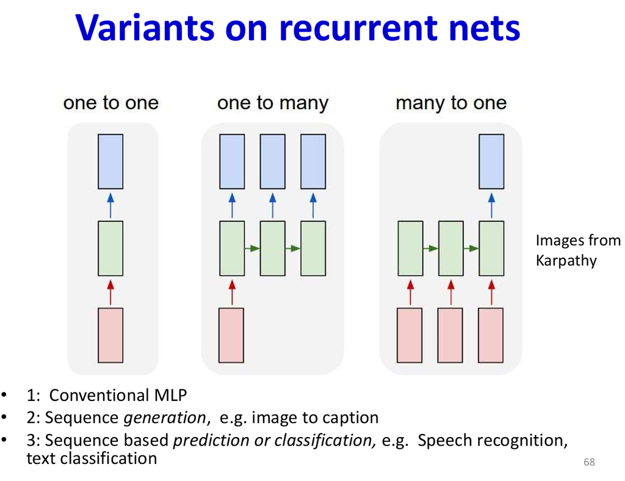

# 9. Training Objective for RNNs

## 9.1 Training Data Format

Training data consists of **input–output sequence pairs**:

$$ \big(X^{(i)}, D^{(i)}\big) \quad \text{for } i = 1, 2, \ldots, N $$

where: $$ \begin{aligned} X^{(i)} &= \{x^{(i)}(0), x^{(i)}(1), \ldots, x^{(i)}(T_i)\} \\ D^{(i)} &= \{d^{(i)}(0), d^{(i)}(1), \ldots, d^{(i)}(T_i)\} \end{aligned} $$

**Notes:**

- Inputs and outputs are **sequences**
- Sequence length $T_i$ **may vary** across training examples
- For many-to-one tasks, $D^{(i)}$ is a single value

## 9.2 Divergence (Loss) Over Sequences

The **divergence** (loss function) is defined over the **entire output sequence**:

$$ \mathcal{D} = \mathcal{D}\big(\{y(0), y(1), \ldots, y(T)\}, \{d(0), d(1), \ldots, d(T)\}\big) $$

**Important:** The divergence is **not necessarily decomposable** into a sum over time steps.

**Common (Decomposable) Case:**

When the loss decomposes over time: $$ \mathcal{D} = \sum_{t=0}^{T} \ell\big(y(t), d(t)\big) $$

where $\ell(\cdot, \cdot)$ is a per-time-step loss:

- **Cross-entropy:** $\ell(y, d) = -\sum_k d_k \log y_k$ for classification
- **Mean squared error:** $\ell(y, d) = \|y - d\|^2$ for regression

## 9.3 Unrolling the RNN for Training

To train an RNN, we **unroll** it through time:

1. Each time step becomes a **layer** in a deep network
2. All layers **share the same parameters**
3. Training becomes standard backpropagation on this deep network

**Unrolled Computational Graph:**

```
    x(0)      x(1)      x(2)           x(T)
      │         │         │              │
      ▼         ▼         ▼              ▼
h(-1)→[f]→h(0)→[f]→h(1)→[f]→h(2)→...→[f]→h(T)
             │         │              │
             ▼         ▼              ▼
           y(0)      y(1)           y(T)
             │         │              │
             ▼         ▼              ▼
           ℓ(0)      ℓ(1)           ℓ(T)
                        \             /
                         \   ...    /
                          ▼       ▼
                             𝒟
```

**Key Consequence:** Gradients must be **pooled (summed) across time** for shared parameters.

## 9.4 Forward Pass (Single Hidden Layer)

**Initialization:** $$ h(-1) = h_{\text{init}} \quad \text{(often } \mathbf{0} \text{ or learned)} $$

**For each time step** $t = 0, 1, \ldots, T$:

**Pre-activation:** $$ z(t) = W_c \, x(t) + W_r \, h(t-1) + b $$

**Hidden state:** $$ h(t) = \tanh\big(z(t)\big) $$

**Output:** $$ y(t) = f_o\big(W_o \, h(t) + b_o\big) $$

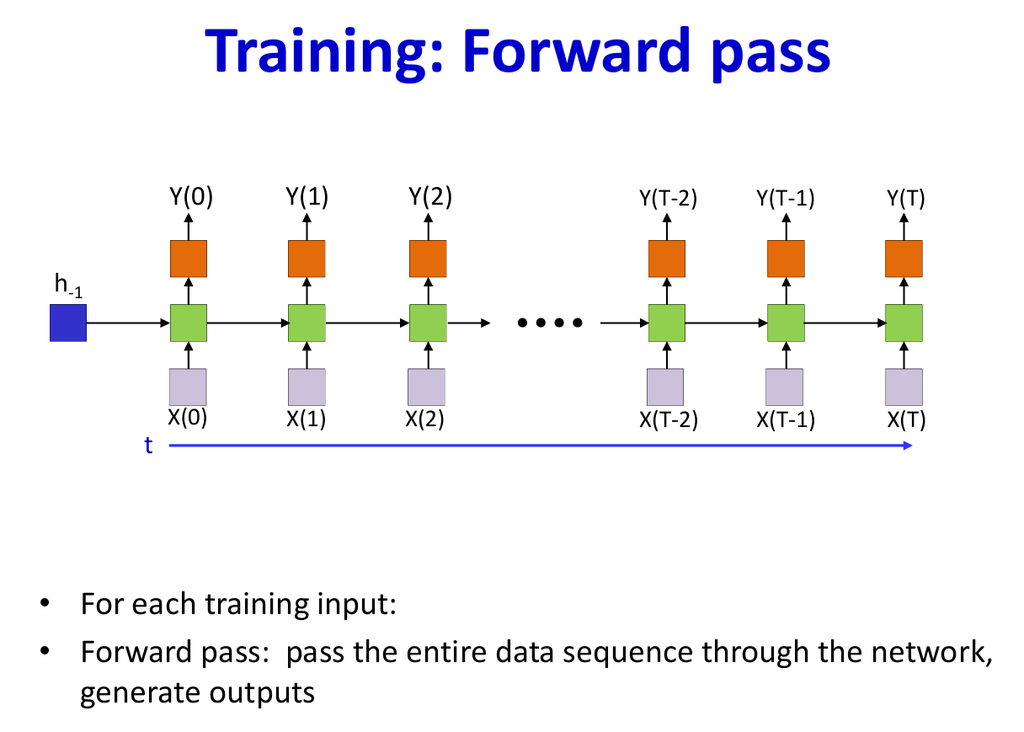

# 10. Backpropagation Through Time (BPTT)

## 10.1 Why BPTT?

Standard backpropagation computes gradients by propagating errors **backward through the network**. For RNNs:

1. The network is **unrolled** through time
2. Errors propagate both **backward through layers** and **backward through time**
3. This is called **Backpropagation Through Time (BPTT)**

## 10.2 Computing Output Gradients

Let $z_o(t) = W_o h(t) + b_o$ be the output pre-activation.

**Output error (gradient at output layer):** $$ \delta_o(t) = \frac{\partial \mathcal{D}}{\partial z_o(t)} = \frac{\partial \mathcal{D}}{\partial y(t)} \cdot \frac{\partial y(t)}{\partial z_o(t)} $$

**Special case (softmax + cross-entropy):** $$ \delta_o(t) = y(t) - d(t) $$

## 10.3 Hidden State Error Recursion

**Key Insight:** The hidden state $h(t)$ influences:

1. The **current output** $y(t)$ directly
2. **All future hidden states** $h(t+1), h(t+2), \ldots$ through the recurrence

Therefore, the total gradient w.r.t. $h(t)$ must account for **both contributions**.

**Total derivative:** $$ \frac{\partial \mathcal{D}}{\partial h(t)} = \underbrace{\frac{\partial \mathcal{D}}{\partial y(t)} \cdot \frac{\partial y(t)}{\partial h(t)}}_{\text{direct influence on output}} + \underbrace{\frac{\partial \mathcal{D}}{\partial h(t+1)} \cdot \frac{\partial h(t+1)}{\partial h(t)}}_{\text{influence through future}} $$

## 10.4 Detailed BPTT Derivation

**Pre-activation gradient:**

Define $\delta_h(t) = \frac{\partial \mathcal{D}}{\partial z(t)}$ as the error at the hidden pre-activation.

**Backward recursion (from $t = T$ down to $t = 0$):**

$$ \boxed{ \delta_h(t) = \Big(W_o^\top \delta_o(t) + W_r^\top \delta_h(t+1)\Big) \odot \tanh'\big(z(t)\big) } $$

where:

- $\tanh'(z) = 1 - \tanh^2(z)$
- $\odot$ denotes element-wise (Hadamard) product
- At $t = T$: $\delta_h(T+1) = \mathbf{0}$ (no future states)

**Breaking down the equation:**

- $W_o^\top \delta_o(t)$: Error from the **output at current time**
- $W_r^\top \delta_h(t+1)$: Error from **future time steps** (through recurrence)
- $\tanh'(z(t))$: Local gradient of the activation

## 10.5 Parameter Gradient Accumulation

Since parameters are **shared across all time steps**, gradients must be **summed**:

**Current weights:** $$ \frac{\partial \mathcal{D}}{\partial W_c} = \sum_{t=0}^{T} \delta_h(t) \, x(t)^\top $$

**Recurrent weights:** $$ \frac{\partial \mathcal{D}}{\partial W_r} = \sum_{t=0}^{T} \delta_h(t) \, h(t-1)^\top $$

**Hidden bias:** $$ \frac{\partial \mathcal{D}}{\partial b} = \sum_{t=0}^{T} \delta_h(t) $$

**Output weights:** $$ \frac{\partial \mathcal{D}}{\partial W_o} = \sum_{t=0}^{T} \delta_o(t) \, h(t)^\top $$

**Output bias:** $$ \frac{\partial \mathcal{D}}{\partial b_o} = \sum_{t=0}^{T} \delta_o(t) $$

## 10.6 Key Difficulties of BPTT

### Vanishing Gradients

The gradient at time $t$ depends on gradients from times $t+1, t+2, \ldots, T$. Each step multiplies by $W_r^\top$ and $\tanh'(z)$.

**Problem:** If $\|W_r\| < 1$ and $|\tanh'(z)| < 1$, repeated multiplication **shrinks** gradients exponentially: $$ \|\delta_h(t)\| \approx \|\delta_h(T)\| \cdot \prod_{\tau=t}^{T-1} \|W_r^\top\| \cdot \|\tanh'(z(\tau))\| \to 0 $$

**Effect:** Early time steps receive **negligible gradients**, preventing learning of long-term dependencies.

### Exploding Gradients

**Problem:** If eigenvalues of $W_r$ exceed 1, gradients **grow exponentially**.

**Effect:** Training becomes unstable; weights diverge.

**Mitigation:**

- **Gradient clipping:** Cap gradient norms
- **Careful initialization**
- **Gated architectures** (LSTM, GRU)

## 10.7 BPTT Algorithm Summary

**Input:** Training sequence $(X, D)$, current parameters $\theta$

**Forward Pass:**

1. Initialize $h(-1) = h_{\text{init}}$
2. For $t = 0$ to $T$:
   - Compute $z(t) = W_c x(t) + W_r h(t-1) + b$
   - Compute $h(t) = \tanh(z(t))$
   - Compute $y(t) = f_o(W_o h(t) + b_o)$
   - Store $z(t), h(t), y(t)$ for backward pass

**Backward Pass:**

1. Initialize $\delta_h(T+1) = \mathbf{0}$
2. For $t = T$ down to $0$:
   - Compute $\delta_o(t) = \frac{\partial \mathcal{D}}{\partial z_o(t)}$
   - Compute $\delta_h(t) = (W_o^\top \delta_o(t) + W_r^\top \delta_h(t+1)) \odot \tanh'(z(t))$
3. Accumulate parameter gradients:
   - $\nabla_{W_c} = \sum_t \delta_h(t) x(t)^\top$
   - $\nabla_{W_r} = \sum_t \delta_h(t) h(t-1)^\top$
   - $\nabla_b = \sum_t \delta_h(t)$
   - $\nabla_{W_o} = \sum_t \delta_o(t) h(t)^\top$
   - $\nabla_{b_o} = \sum_t \delta_o(t)$

**Update:** $\theta \leftarrow \theta - \eta \nabla_\theta \mathcal{D}$

# 11. Bidirectional Recurrent Neural Networks (BRNNs)

## 11.1 Motivation

In some problems, the **entire input sequence is known in advance**. The output at time $t$ may depend on:

- **Past context:** $x(0), x(1), \ldots, x(t-1)$
- **Future context:** $x(t+1), x(t+2), \ldots, x(T)$

**Examples:**

- **Speech recognition:** Future phonemes disambiguate current ones
- **NLP tagging:** Part-of-speech depends on surrounding words
- **Named-entity recognition:** Entity type depends on full context
- **Handwriting recognition:** Future strokes help identify current characters

> A standard (unidirectional) RNN only sees the **past**. A Bidirectional RNN sees **both past and future**.

## 11.2 Architecture

A **Bidirectional RNN (BRNN)** consists of two **independent** RNNs:

1. **Forward RNN:** Processes sequence left-to-right ($t = 0 \to T$)
2. **Backward RNN:** Processes sequence right-to-left ($t = T \to 0$)

**Important:** These networks do **not** share parameters.

```
           Forward RNN (→)
x(0) ──► x(1) ──► x(2) ──► ... ──► x(T)
  │        │        │               │
  ▼        ▼        ▼               ▼
h_f(0) ► h_f(1) ► h_f(2) ► ... ► h_f(T)
                      \
                       \  Concatenate
                        ▼
            h(t) = [h_f(t); h_b(t)]
                        ▲
                       /
                      /
h_b(0) ◄ h_b(1) ◄ h_b(2) ◄ ... ◄ h_b(T)
  │        │        │               │
  ▲        ▲        ▲               ▲
x(0) ◄── x(1) ◄── x(2) ◄── ... ◄── x(T)
           Backward RNN (←)
```

## 11.3 Forward Pass Equations

### Forward RNN (Left to Right)

**Hidden state:** $$ h_f(t) = \tanh\big(W_{fc} \, x(t) + W_{fr} \, h_f(t-1) + b_f\big) $$

**Initial state:** $$ h_f(-1) = h_{f,\text{init}} $$

### Backward RNN (Right to Left)

**Hidden state:** $$ h_b(t) = \tanh\big(W_{bc} \, x(t) + W_{br} \, h_b(t+1) + b_b\big) $$

**Initial state:** $$ h_b(T+1) = h_{b,\text{init}} $$

**Critical Note:**

> The backward RNN's forward pass runs from $t = T$ to $t = 0$. This is **not** backpropagation—it is a **forward computation** on reversed time.

## 11.4 Output Construction

At each time step, the forward and backward hidden states are **concatenated**:

$$ h(t) = \begin{bmatrix} h_f(t) \\ h_b(t) \end{bmatrix} \in \mathbb{R}^{2d_h} $$

**Output:** $$ y(t) = f_o\big(W_o \, h(t) + b_o\big) $$

where $W_o \in \mathbb{R}^{d_y \times 2d_h}$ since the concatenated state has dimension $2d_h$.

## 11.5 Loss Function

The divergence is defined over the entire output sequence:

$$ \mathcal{D} = \mathcal{D}\big(\{y(0), \ldots, y(T)\}, \{d(0), \ldots, d(T)\}\big) $$

**Common case:** $$ \mathcal{D} = \sum_{t=0}^{T} \ell\big(y(t), d(t)\big) $$

## 11.6 Key Properties

**Advantages:**

- Uses **full context** (past and future)
- Strong performance in NLP and speech tasks
- Better disambiguation at each time step

**Limitations:**

- **Not online:** Requires the entire input sequence before producing outputs
- **Cannot be used for real-time prediction**
- Higher computation and memory cost (2× the parameters)

[figure not shown]

[figure not shown]

[figure not shown]

[figure not shown]

[figure not shown]

[figure not shown]

[figure not shown]

[figure not shown]

[figure not shown]

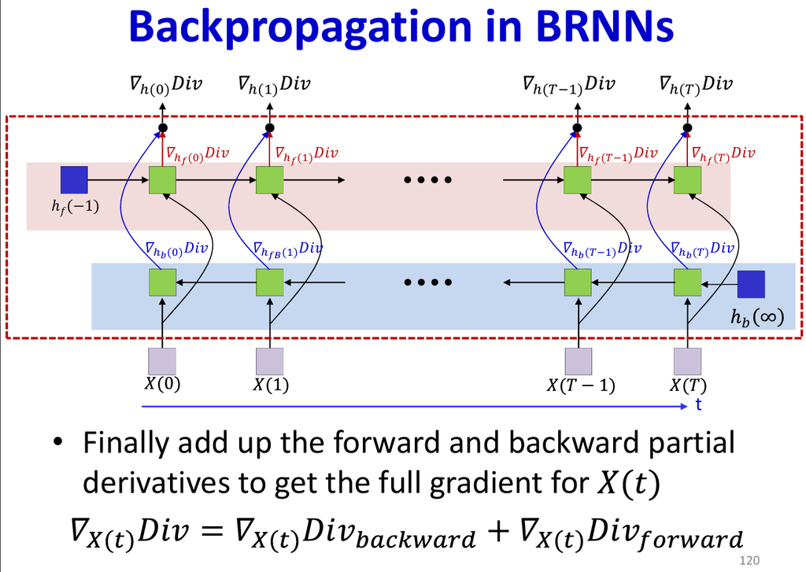

# 12. Backpropagation in Bidirectional RNNs

## 12.1 High-Level Strategy

Backpropagation in BRNNs proceeds in **three stages**:

1. **Backprop from output to combined hidden state**
2. **Split gradients** into forward and backward components
3. **Apply BPTT separately** to each RNN

## 12.2 Gradient at the Output Layer

Let $z_o(t) = W_o h(t) + b_o$ be the output pre-activation.

**Output gradient:** $$ \delta_o(t) = \frac{\partial \mathcal{D}}{\partial z_o(t)} = \frac{\partial \mathcal{D}}{\partial y(t)} \cdot \frac{\partial y(t)}{\partial z_o(t)} $$

**Gradient w.r.t. combined hidden state:** $$ \frac{\partial \mathcal{D}}{\partial h(t)} = W_o^\top \delta_o(t) $$

## 12.3 Splitting the Hidden-State Gradient

Since $h(t) = [h_f(t); h_b(t)]$, the gradient naturally splits:

$$ \frac{\partial \mathcal{D}}{\partial h(t)} = \begin{bmatrix} \delta_f(t) \\ \delta_b(t) \end{bmatrix} $$

where:

- $\delta_f(t) = \frac{\partial \mathcal{D}}{\partial h_f(t)}$ (gradient for forward hidden state)
- $\delta_b(t) = \frac{\partial \mathcal{D}}{\partial h_b(t)}$ (gradient for backward hidden state)

## 12.4 BPTT for Forward RNN

**Pre-activation:** $$ z_f(t) = W_{fc} \, x(t) + W_{fr} \, h_f(t-1) + b_f $$

**Error recursion (backward in $t$: from $T$ down to $0$):** $$ \delta_f^z(t) = \Big(\delta_f(t) + W_{fr}^\top \delta_f^z(t+1)\Big) \odot \tanh'\big(z_f(t)\big) $$

**Boundary condition:** $\delta_f^z(T+1) = \mathbf{0}$

**Parameter gradients:** $$ \begin{aligned} \frac{\partial \mathcal{D}}{\partial W_{fc}} &= \sum_{t=0}^{T} \delta_f^z(t) \, x(t)^\top \\ \frac{\partial \mathcal{D}}{\partial W_{fr}} &= \sum_{t=0}^{T} \delta_f^z(t) \, h_f(t-1)^\top \\ \frac{\partial \mathcal{D}}{\partial b_f} &= \sum_{t=0}^{T} \delta_f^z(t) \end{aligned} $$

## 12.5 BPTT for Backward RNN

**Pre-activation:** $$ z_b(t) = W_{bc} \, x(t) + W_{br} \, h_b(t+1) + b_b $$

**Error recursion (forward in $t$: from $0$ up to $T$):** $$ \delta_b^z(t) = \Big(\delta_b(t) + W_{br}^\top \delta_b^z(t-1)\Big) \odot \tanh'\big(z_b(t)\big) $$

**Boundary condition:** $\delta_b^z(-1) = \mathbf{0}$

**Note:** The gradient flows in the **opposite direction** to the backward RNN's forward pass.

**Parameter gradients:** $$ \begin{aligned} \frac{\partial \mathcal{D}}{\partial W_{bc}} &= \sum_{t=0}^{T} \delta_b^z(t) \, x(t)^\top \\ \frac{\partial \mathcal{D}}{\partial W_{br}} &= \sum_{t=0}^{T} \delta_b^z(t) \, h_b(t+1)^\top \\ \frac{\partial \mathcal{D}}{\partial b_b} &= \sum_{t=0}^{T} \delta_b^z(t) \end{aligned} $$

## 12.6 Gradient w.r.t. Inputs

If gradients w.r.t. inputs are needed (e.g., for stacking bidirectional layers), inputs receive gradients from **both directions**:

$$ \frac{\partial \mathcal{D}}{\partial x(t)} = W_{fc}^\top \delta_f^z(t) + W_{bc}^\top \delta_b^z(t) $$

## 12.7 Important Clarification

**The backward RNN's "forward pass" is NOT backpropagation.**

| Operation | Direction | Purpose |
| --- | --- | --- |
| Forward RNN forward pass | $t: 0 \to T$ | Compute $h_f(t)$ |
| Backward RNN forward pass | $t: T \to 0$ | Compute $h_b(t)$ |
| Forward RNN BPTT | $t: T \to 0$ | Compute $\delta_f^z(t)$ |
| Backward RNN BPTT | $t: 0 \to T$ | Compute $\delta_b^z(t)$ |

# 13. Summary and Conceptual Unification

## 13.1 Evolution of Sequence Models

| Model Type | Memory | Response | Trainable | Gradient Flow |
| --- | --- | --- | --- | --- |
| Sliding Window / TDNN | Window of inputs | Finite | N/A | Standard BP |
| NARX | Output feedback | Infinite | Limited | Limited |
| Jordan | Fixed memory unit | Infinite | ✗ | Blocked |
| Elman | Context unit | Infinite | Partial | Blocked |
| **State-Space RNN** | **Learned hidden state** | **Infinite** | **✓** | **Full (BPTT)** |
| **Bidirectional RNN** | **Two hidden states** | **Infinite (both directions)** | **✓** | **Full (BPTT)** |

## 13.2 Key Equations Reference

### Single-Layer RNN Forward Pass

$$ \begin{aligned} z(t) &= W_c \, x(t) + W_r \, h(t-1) + b \\ h(t) &= \tanh\big(z(t)\big) \\ y(t) &= f_o\big(W_o \, h(t) + b_o\big) \end{aligned} $$

### BPTT Hidden Error Recursion

$$ \delta_h(t) = \Big(W_o^\top \delta_o(t) + W_r^\top \delta_h(t+1)\Big) \odot \tanh'\big(z(t)\big) $$

### Parameter Gradients

$$ \begin{aligned} \nabla_{W_c} \mathcal{D} &= \sum_{t=0}^{T} \delta_h(t) \, x(t)^\top \\ \nabla_{W_r} \mathcal{D} &= \sum_{t=0}^{T} \delta_h(t) \, h(t-1)^\top \\ \nabla_b \mathcal{D} &= \sum_{t=0}^{T} \delta_h(t) \end{aligned} $$

### Bidirectional RNN

$$ h(t) = \begin{bmatrix} h_f(t) \\ h_b(t) \end{bmatrix}, \quad y(t) = f_o\big(W_o \, h(t) + b_o\big) $$

## 13.3 Core Principles

1. **State-space RNNs** introduce **trainable internal memory** via hidden states
2. **Hidden states** store a **compressed representation** of the past
3. **Recurrence** provides **infinite memory** capacity
4. **BPTT** enables learning by propagating gradients through time
5. **Parameter sharing** across time requires **gradient accumulation**
6. **Bidirectional RNNs** exploit **both past and future context**
7. **Vanishing/exploding gradients** are fundamental challenges addressed by gated architectures (LSTM, GRU)

## 13.4 Design Decisions Summary

| Design Choice | Options | Trade-off |
| --- | --- | --- |
| Hidden dimension $d_h$ | Small vs. large | Capacity vs. computation |
| Number of layers $L$ | Shallow vs. deep | Expressiveness vs. training difficulty |
| Activation | tanh, ReLU | Gradient flow vs. bounded states |
| Initial state | Zero, learned | Simplicity vs. flexibility |
| Architecture | Unidirectional vs. Bidirectional | Online capability vs. accuracy |

## 13.5 Final Takeaways

**RNNs are trained using backpropagation through time**, which:

1. **Unrolls** the network across time
2. **Propagates** sequence-level errors backward
3. **Aggregates** gradients for shared parameters

**Bidirectional RNNs** enhance performance by:

1. Using two independent recurrent networks
2. Processing sequences in **both directions**
3. **Concatenating** hidden states at each time step
4. Applying **separate BPTT** in each direction

**Key Insight:**

> The hidden state $h(t)$ is the learned representation of the sequence history. Training optimizes what information to store and how to update it.

*End of Lecture Notes on Recurrent Neural Networks*